# HW-9 (answer key: Titanic-PCA)

[Titanic competition from Kaggle](https://www.kaggle.com/c/titanic).

Instructor: [Pedram Jahangiry](https://github.com/PJalgotrader)

### Importing Packages

```python
import numpy as np
import pandas as pd
import matplotlib.pyplot as plt
import seaborn as sns

sns.set()  #if you want to use seaborn themes with matplotlib functions
```

### Data Preprocessing

```python
df = pd.read_csv('titanic_train_clean.csv')
```

```python
df.head()
```

|  | PassengerId | Survived | Age | SibSp | Parch | Fare | Cabin_known | Pclass_2 | Pclass_3 | Sex_male | Embarked_Q | Embarked_S |
| --- | --- | --- | --- | --- | --- | --- | --- | --- | --- | --- | --- | --- |
| 0 | 1 | 0 | 22.0 | 1 | 0 | 7.2500 | 0 | 0 | 1 | 1 | 0 | 1 |
| 1 | 2 | 1 | 38.0 | 1 | 0 | 71.2833 | 1 | 0 | 0 | 0 | 0 | 0 |
| 2 | 3 | 1 | 26.0 | 0 | 0 | 7.9250 | 0 | 0 | 1 | 0 | 0 | 1 |
| 3 | 4 | 1 | 35.0 | 1 | 0 | 53.1000 | 1 | 0 | 0 | 0 | 0 | 1 |
| 4 | 5 | 0 | 35.0 | 0 | 0 | 8.0500 | 0 | 0 | 1 | 1 | 0 | 1 |

```python
df.info()
```

```
<class 'pandas.core.frame.DataFrame'>
RangeIndex: 889 entries, 0 to 888
Data columns (total 12 columns):
PassengerId    889 non-null int64
Survived       889 non-null int64
Age            889 non-null float64
SibSp          889 non-null int64
Parch          889 non-null int64
Fare           889 non-null float64
Cabin_known    889 non-null int64
Pclass_2       889 non-null int64
Pclass_3       889 non-null int64
Sex_male       889 non-null int64
Embarked_Q     889 non-null int64
Embarked_S     889 non-null int64
dtypes: float64(2), int64(10)
memory usage: 83.4 KB
```

### Dealing with categorical variables:

For PCA we should convert categorical variables into dummies (one-hot-encoding). However, be aware that this is not the best approach to deal with categorical variables in PCA. There are more advanced techniques which is beyond the scope of our class.

Note that the categorical variables in our clean dataset come as dummy variables (one-hot-endoding) already.

# Questions:

- 1- Use PCA function from Sklearn package and apply it to the training data set. Report the loading vectors!
- 2- Use the scree plot and find the optimal number of principle components. Make some comments!
- 3- Repeat question 1 and 2 using Kernel PCA. Compare the results between PCA and Kernel PCA.

Note that we need to drop the target variable from our data frame first! We also need to drop the passenger ID variable.

```python
df.drop(["Survived","PassengerId"], axis=1, inplace=True)
```

```python
df.shape
```

```
(889, 10)
```

We need to scale our feature space first!

```python
from sklearn.preprocessing import StandardScaler
sc = StandardScaler()
X_sc = sc.fit_transform(df)
```

```python
from sklearn.decomposition import PCA
```

```python
pca=PCA(n_components=10)
pca.fit(X_sc)
```

```
PCA(copy=True, iterated_power='auto', n_components=10, random_state=None,
    svd_solver='auto', tol=0.0, whiten=False)
```

```python
print(pca.components_)
```

```
[[ 0.30952374 -0.02126177  0.08245209  0.43678363  0.49138944  0.19768422
  -0.58325247 -0.16228332 -0.24183452  0.0248762 ]
 [-0.29703018  0.4682014   0.48216268  0.32844017  0.1227077  -0.29461486
   0.15321711 -0.35458907  0.18670437 -0.2574572 ]
 [ 0.23042602 -0.33808782 -0.34078456  0.10875476  0.22972363 -0.32196591
   0.02826972  0.01935505  0.46843235 -0.57236449]
 [-0.16500506 -0.04879673  0.02694015 -0.17617185 -0.25996535  0.64675688
  -0.27185109 -0.40060671  0.38122399 -0.27024617]
 [ 0.01818449  0.44377829  0.04831852  0.16451022 -0.08098297  0.22847261
  -0.17961467  0.76644512  0.21638793 -0.21920446]
 [ 0.82071069  0.16582353  0.37545291 -0.2256278  -0.17001637 -0.03369019
   0.10423322 -0.10792622  0.21398594  0.0933837 ]
 [-0.0856395  -0.63608269  0.66181711  0.12778423 -0.12912486  0.04877702
   0.03915931  0.25959507 -0.10742262 -0.18498347]
 [ 0.20028379  0.02830483 -0.24276101  0.55895716 -0.63842048  0.0202255
   0.12043104 -0.14199494 -0.31694849 -0.21120345]
 [-0.05834984 -0.18382469 -0.03516518  0.47430056 -0.08846989  0.01609391
   0.03872132  0.01937616  0.57762393  0.62689397]
 [ 0.1043847   0.00451717 -0.04888725  0.16367207  0.39443585  0.54386072
   0.70779691  0.0075212  -0.06031463 -0.06220865]]
```

```python
 print(pca.explained_variance_ratio_)
```

```
[0.22783982 0.17884646 0.16575822 0.12216903 0.07874922 0.07069805
 0.05576968 0.04890284 0.0413509  0.00991578]
```

```python
# we could have constructed the explained_variance ratio mannually!
PC_df= pca.fit_transform(X_sc)
Explained_variance = np.var(PC_df, axis=0)
Explained_var_ratio = Explained_variance / np.sum(Explained_variance)
Explained_var_ratio
```

```
array([0.22783982, 0.17884646, 0.16575822, 0.12216903, 0.07874922,
       0.07069805, 0.05576968, 0.04890284, 0.0413509 , 0.00991578])
```

Note that one of the componenets of pca is pca.explained_variance_ratio so we didn't need to calculate the PVE mannually. However for kpca we have to do it mannually as there is no specific function for that.

```python
PVE=pd.DataFrame({'PVE':pca.explained_variance_ratio_, 'Principal Component':range(1,pca.n_components+1)})
PVE
```

|  | PVE | Principal Component |
| --- | --- | --- |
| 0 | 0.227840 | 1 |
| 1 | 0.178846 | 2 |
| 2 | 0.165758 | 3 |
| 3 | 0.122169 | 4 |
| 4 | 0.078749 | 5 |
| 5 | 0.070698 | 6 |
| 6 | 0.055770 | 7 |
| 7 | 0.048903 | 8 |
| 8 | 0.041351 | 9 |
| 9 | 0.009916 | 10 |

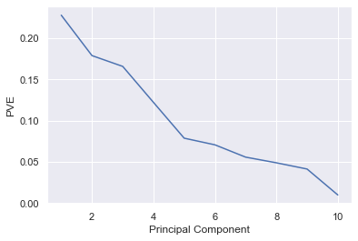

```python
sns.lineplot(x='Principal Component', y='PVE', data=PVE)
plt.show()
```

Looking at the above plot it seems that it would be beneficial to include at least 5 PCs. Almost 80% of the variations in the feature space is explained by 5 components.

# Kernel PCA

```python
from sklearn.decomposition import KernelPCA
kpca = KernelPCA(n_components=10,kernel = 'rbf')
KPC_df= kpca.fit_transform(X_sc)
```

```python
kpca.alphas_
```

```
array([[ 0.04911452,  0.00109079, -0.0014053 , ...,  0.00106834,
        -0.00921455, -0.03895624],
       [-0.03852796, -0.03158848,  0.04713874, ...,  0.07685345,
        -0.06236166, -0.05249475],
       [ 0.02458331, -0.00826857, -0.01132499, ..., -0.03847341,
        -0.04127818,  0.01852317],
       ...,
       [-0.00422645, -0.01905889, -0.01968225, ..., -0.03257057,
         0.00818633,  0.07769919],
       [-0.02488144, -0.02239592,  0.04736331, ..., -0.01906589,
        -0.00750679, -0.02351205],
       [-0.02062023, -0.05504399, -0.06090638, ...,  0.00714844,
         0.01904065, -0.02121453]])
```

```python
KPC_df.shape
```

```
(889, 10)
```

```python
# we could have constructed the explained_variance ratio mannually!
KPC_df= kpca.fit_transform(X_sc)
Explained_variance = np.var(KPC_df, axis=0)
Explained_var_ratio = Explained_variance / np.sum(Explained_variance)
Explained_var_ratio
```

```
array([0.29160283, 0.16626516, 0.13478814, 0.09967282, 0.07100946,
       0.06615127, 0.05583293, 0.04456492, 0.03828656, 0.03182591])
```

```python
KPVE=pd.DataFrame({'PVE':Explained_var_ratio, 'Principal Component':range(1,kpca.n_components+1)})
KPVE
```

|  | PVE | Principal Component |
| --- | --- | --- |
| 0 | 0.291603 | 1 |
| 1 | 0.166265 | 2 |
| 2 | 0.134788 | 3 |
| 3 | 0.099673 | 4 |
| 4 | 0.071009 | 5 |
| 5 | 0.066151 | 6 |
| 6 | 0.055833 | 7 |
| 7 | 0.044565 | 8 |
| 8 | 0.038287 | 9 |
| 9 | 0.031826 | 10 |

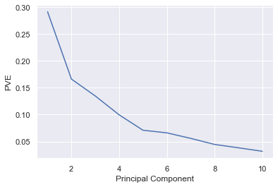

```python
sns.lineplot(x='Principal Component', y='PVE', data=KPVE)
plt.show()
```

Looking at the above plot it seems that again 5 PCs makes sense in the KPCA

```python
PVE['type']='PVE'
KPVE['type']='KPVE'
```

```python
compare=pd.concat([PVE, KPVE])
```

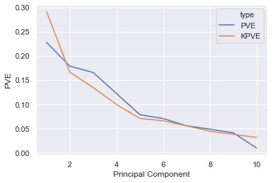

```python
sns.lineplot(x='Principal Component', y='PVE', hue='type', data=compare)
plt.show()
```

```python
compare2=pd.concat([PVE['PVE'], KPVE['PVE']], axis=1)
compare2.columns = ['PVE_PCA', 'PVE_KPCA']
compare2
```

|  | PVE_PCA | PVE_KPCA |
| --- | --- | --- |
| 0 | 0.227840 | 0.291603 |
| 1 | 0.178846 | 0.166265 |
| 2 | 0.165758 | 0.134788 |
| 3 | 0.122169 | 0.099673 |
| 4 | 0.078749 | 0.071009 |
| 5 | 0.070698 | 0.066151 |
| 6 | 0.055770 | 0.055833 |
| 7 | 0.048903 | 0.044565 |
| 8 | 0.041351 | 0.038287 |
| 9 | 0.009916 | 0.031826 |

For a better comparison, we can look at the cumulative PVE side by side:

```python
compare2.cumsum()
```

|  | PVE_PCA | PVE_KPCA |
| --- | --- | --- |
| 0 | 0.227840 | 0.291603 |
| 1 | 0.406686 | 0.457868 |
| 2 | 0.572444 | 0.592656 |
| 3 | 0.694614 | 0.692329 |
| 4 | 0.773363 | 0.763338 |
| 5 | 0.844061 | 0.829490 |
| 6 | 0.899830 | 0.885323 |
| 7 | 0.948733 | 0.929888 |
| 8 | 0.990084 | 0.968174 |
| 9 | 1.000000 | 1.000000 |

So it seems that PCA and KPCA are very close to each other. However, if PC <= 3, KPC is doing a better job.